# Clinical Data Exploration

Carlos Ruiz

2024-03-20

# Introduction

In this document, I will explore the clinical variables present in the IPPSmol dataset.

# Data loading

```r
library(tidyverse)
library(GGally)
library(survival)
library(survminer)
library(cowplot)
```

```r
load("../results/preprocess/clinical_preproc.Rdata")
```

```r
colnames(clinical_all)
```

```
##   [1] "ID"                      "MDS_TYPE"
##   [3] "SEX"                     "AGE"
##   [5] "WHO_2016"                "BM_BLAST"
##   [7] "PB_BLAST"                "WBC"
##   [9] "ANC"                     "MONOCYTES"
##  [11] "HB"                      "PLT"
##  [13] "RINGED_SIDEROBLASTS"     "IPSSR"
##  [15] "IPSSR_SCORE"             "IPSSRA"
##  [17] "IPSSRA_SCORE"            "IPSSM"
##  [19] "IPSSM_SCORE"             "CYTOGENETICS"
##  [21] "CYTO_IPSSR"              "complex"
##  [23] "chr17"                   "CNACS_chrarm_loss"
##  [25] "CNACS_gene_loss"         "CNACS_chrarm_gain"
##  [27] "CNACS_gene_gain"         "CNACS_chrarm_upd"
##  [29] "CNACS_gene_upd"          "OS_YEARS"
```

[output cut: 50 more lines]

The dataset contains 2957 individuals and 130 variables.

# Data exploration

Define functions

```r
plot_continuous <- function(var, binwidth){
  ggplot(clinical_all, aes(x = .data[[var]])) +
    geom_histogram(binwidth = binwidth) +
    theme_bw()
}

descrip_continuous <- function(var, thres){
  clinical_all %>%
    mutate(intervals = cut_interval(.data[[var]], thres)) %>%
    count(intervals) %>%
    mutate(perc = round(n/sum(n)*100, 1))
}


plot_categorical <- function(var){
  ggplot(clinical_all, aes(x = .data[[var]])) +
    geom_bar() +
    theme_bw()
}

descrip_categorical <- function(var){
  clinical_all %>%
    count(.data[[var]]) %>%
    mutate(perc = round(n/sum(n)*100, 1))
}
```

## Demographic variables

The cohort contains two demographic variables: age and sex.

```r
demo_vars <- c("AGE", "SEX")
```

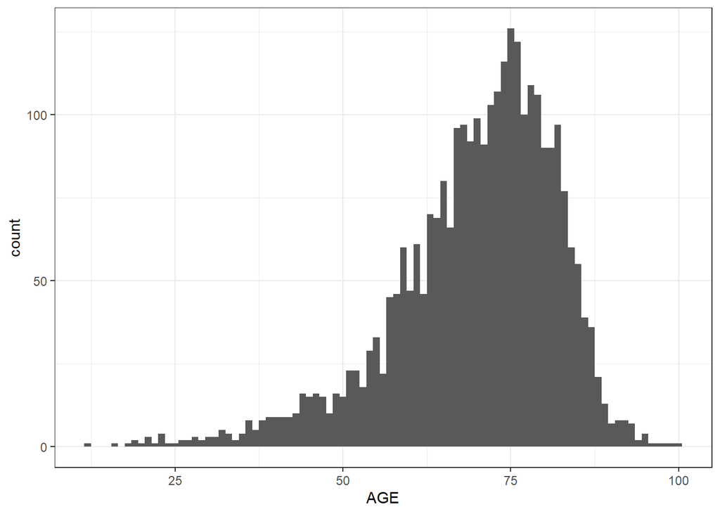

```r
plot_continuous("AGE", 1)
```

```r
descrip_continuous("AGE", 10)
```

```
## # A tibble: 11 × 3
##    intervals       n  perc
##    <fct>       <int> <dbl>
##  1 [12,20.8]       6   0.2
##  2 (20.8,29.6]    19   0.6
##  3 (29.6,38.4]    42   1.4
##  4 (38.4,47.2]   108   3.7
##  5 (47.2,56]     189   6.4
##  6 (56,64.8]     444  15
##  7 (64.8,73.6]   831  28.1
##  8 (73.6,82.4]   956  32.3
##  9 (82.4,91.2]   316  10.7
## 10 (91.2,100]     26   0.9
## 11 <NA>           20   0.7
```

Most individuals are between 56 and 90 years old. Nonetheless, 11.64% of the individuals are younger than 56, being 0.85% younger than 30. In addition, 0.68% have missing age.

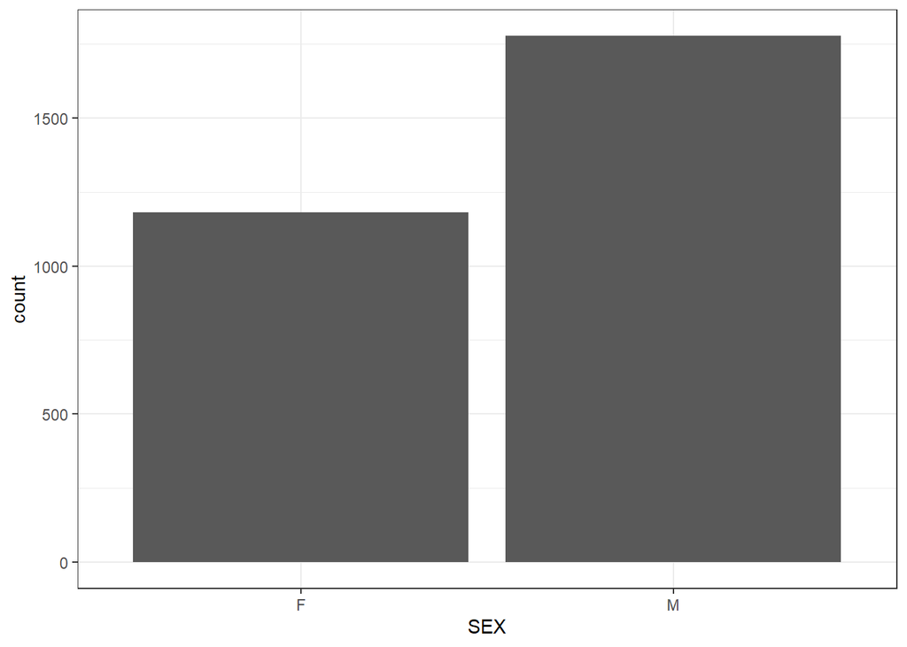

```r
plot_categorical("SEX")
```

```r
descrip_categorical("SEX")
```

```
## # A tibble: 2 × 3
##   SEX       n  perc
##   <chr> <int> <dbl>
## 1 F      1181  39.9
## 2 M      1776  60.1
```

There are more men than woman.

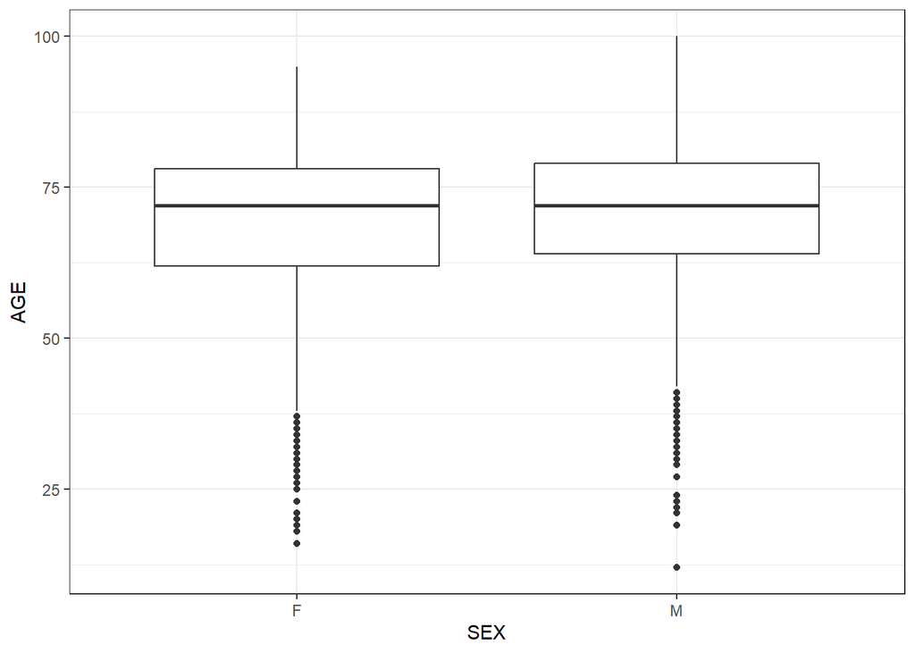

```r
ggplot(clinical_all, aes(x = SEX, y = AGE)) +
  geom_boxplot() +
  theme_bw()
```

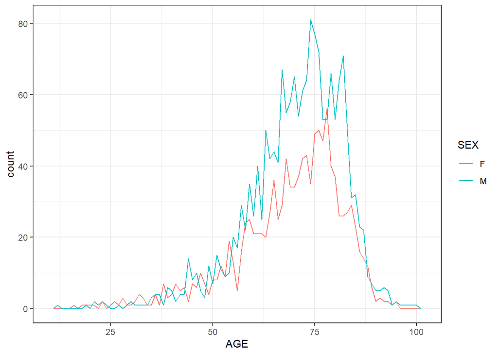

```r
ggplot(clinical_all, aes(x = AGE, color = SEX)) +
 geom_freqpoly( binwidth = 1) + theme_bw()
```

The age distribution seems very similar in men than women

## Clinical variables

```r
clin_vars <- c("BM_BLAST", "PB_BLAST", "WBC", "ANC", "MONOCYTES", "HB", "PLT")
```

### Bone marrow blasts (%)

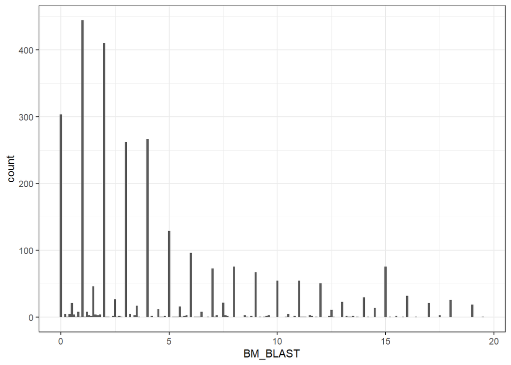

```r
plot_continuous("BM_BLAST", 0.1)
```

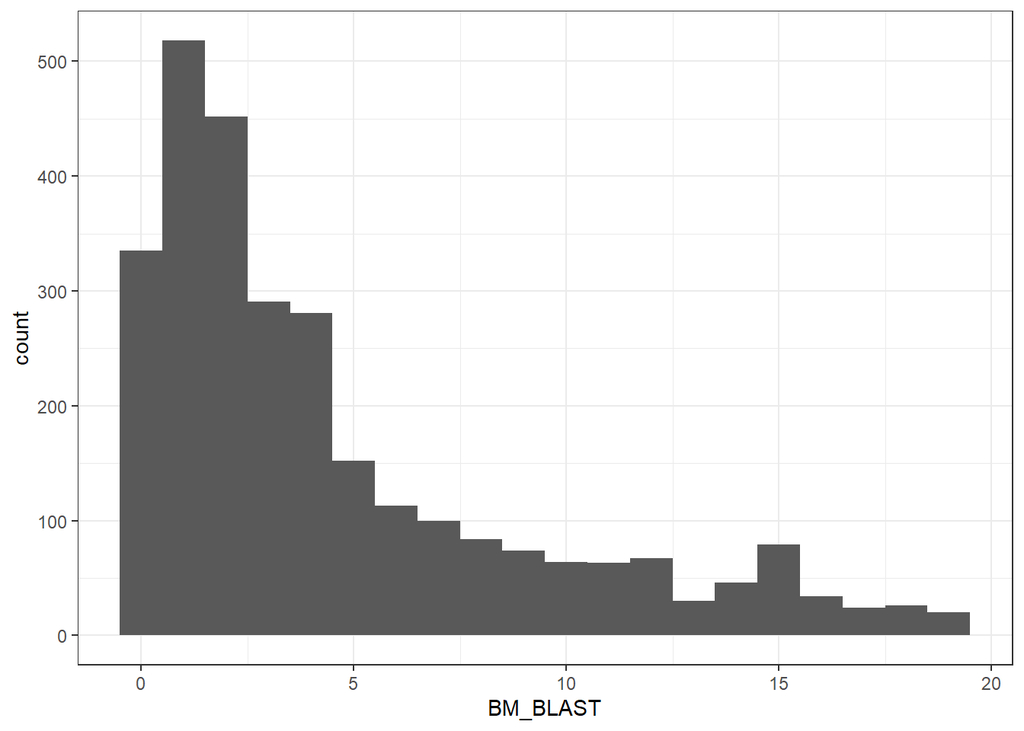

```r
plot_continuous("BM_BLAST", 1)
```

```r
descrip_continuous("BM_BLAST", 10)
```

```
## # A tibble: 11 × 3
##    intervals       n  perc
##    <fct>       <int> <dbl>
##  1 [0,1.95]      864  29.2
##  2 (1.95,3.9]    733  24.8
##  3 (3.9,5.85]    438  14.8
##  4 (5.85,7.8]    212   7.2
##  5 (7.8,9.75]    156   5.3
##  6 (9.75,11.7]   126   4.3
##  7 (11.7,13.6]    95   3.2
##  8 (13.6,15.6]   125   4.2
##  9 (15.6,17.6]    58   2
## 10 (17.6,19.5]    46   1.6
## 11 <NA>          104   3.5
```

Bone marrow blasts show a tail distribution, with most individuals between 0 and 5% but a tail up to 20%.

### Peripheral blood blasts (%)

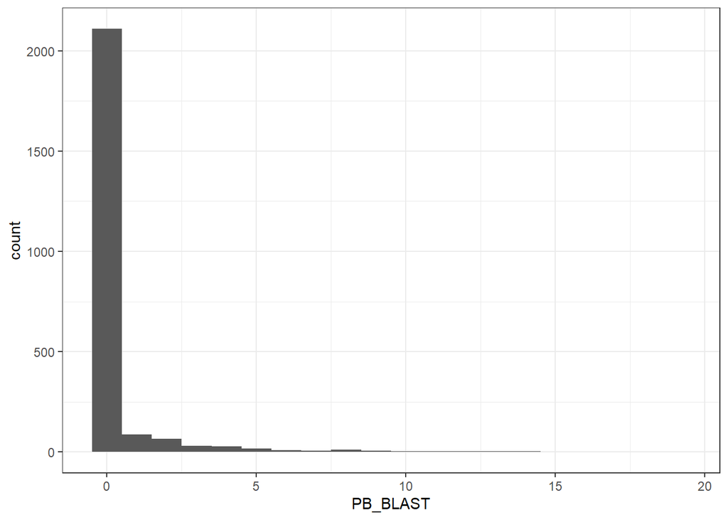

```r
plot_continuous("PB_BLAST", 1)
```

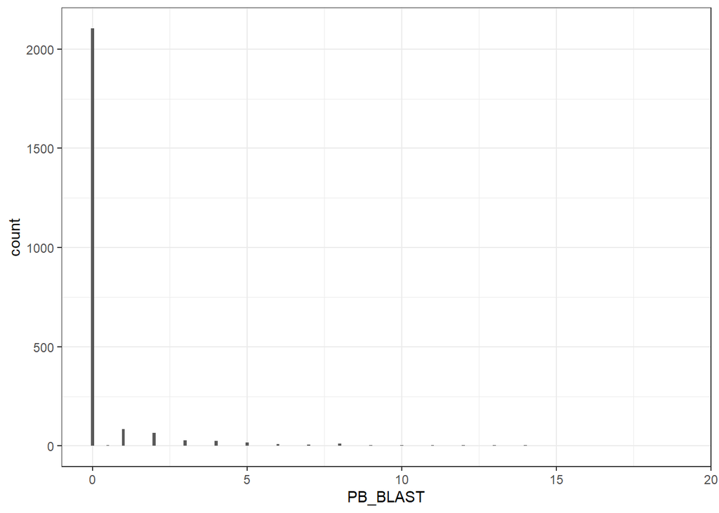

```r
plot_continuous("PB_BLAST", 0.1)
```

```r
descrip_continuous("PB_BLAST", 10)
```

```
## # A tibble: 11 × 3
##    intervals       n  perc
##    <fct>       <int> <dbl>
##  1 [0,1.9]      2198  74.3
##  2 (1.9,3.8]      99   3.3
##  3 (3.8,5.7]      44   1.5
##  4 (5.7,7.6]      15   0.5
##  5 (7.6,9.5]      17   0.6
##  6 (9.5,11.4]      8   0.3
##  7 (11.4,13.3]     8   0.3
##  8 (13.3,15.2]     4   0.1
##  9 (15.2,17.1]     3   0.1
## 10 (17.1,19]       1   0
## 11 <NA>          560  18.9
```

Most individuals did not have blasts in peripheral blood. A high proportion of samples (18.94%) had missing values.

### Whole blood cell counts (Giga/L)

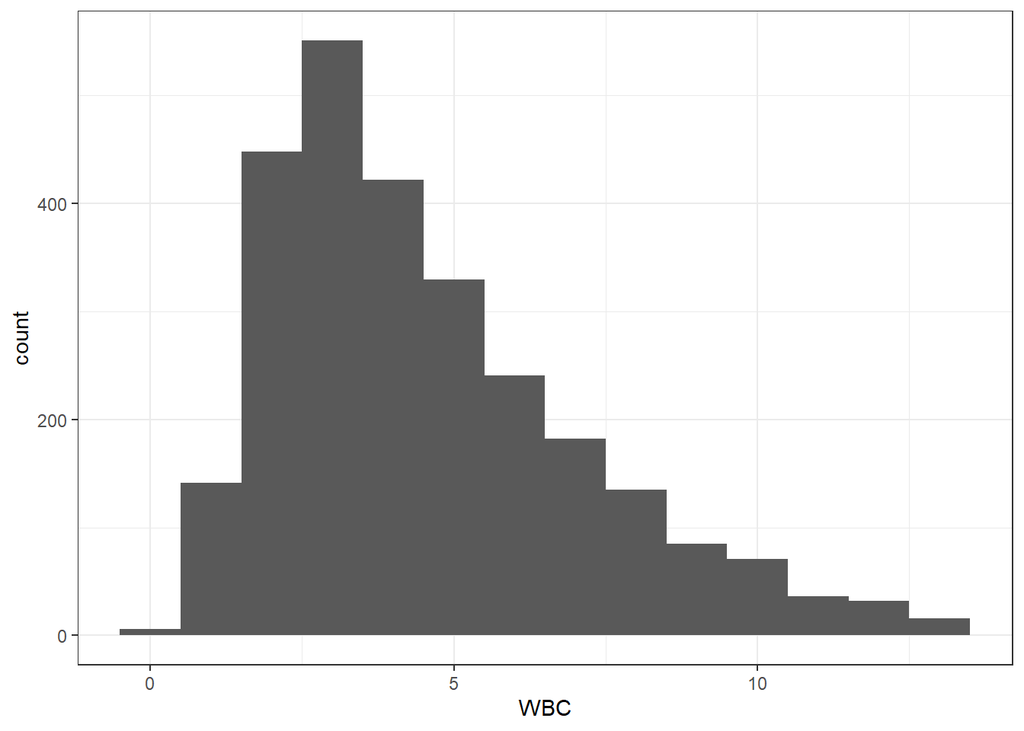

```r
plot_continuous("WBC", 1)
```

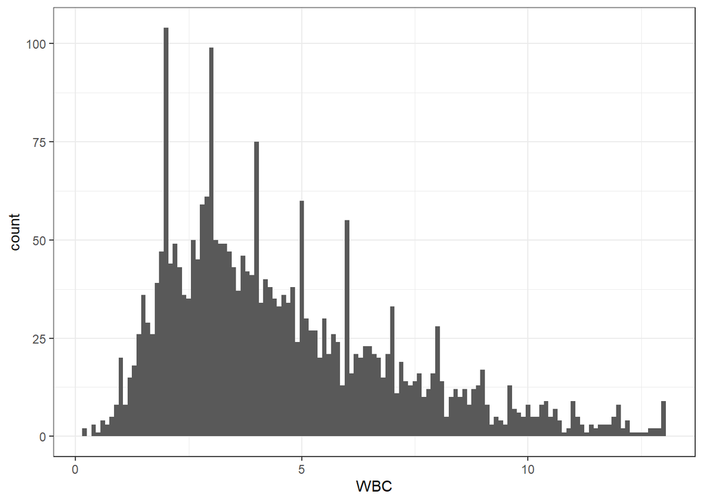

```r
plot_continuous("WBC", 0.1)
```

```r
descrip_continuous("WBC", 10)
```

```
## # A tibble: 11 × 3
##    intervals       n  perc
##    <fct>       <int> <dbl>
##  1 [0.2,1.48]    117   4
##  2 (1.48,2.76]   581  19.6
##  3 (2.76,4.04]   696  23.5
##  4 (4.04,5.32]   455  15.4
##  5 (5.32,6.6]    311  10.5
##  6 (6.6,7.88]    202   6.8
##  7 (7.88,9.16]   164   5.5
##  8 (9.16,10.4]    81   2.7
##  9 (10.4,11.7]    47   1.6
## 10 (11.7,13]      42   1.4
## 11 <NA>          261   8.8
```

Most samples had white blood cell counts between 1.6 and 6.6 Giga/L. A relevant proportion of samples (8.83%) had missing values for white blood cell counts.

### Absolute Neutrophil Count (Giga/L)

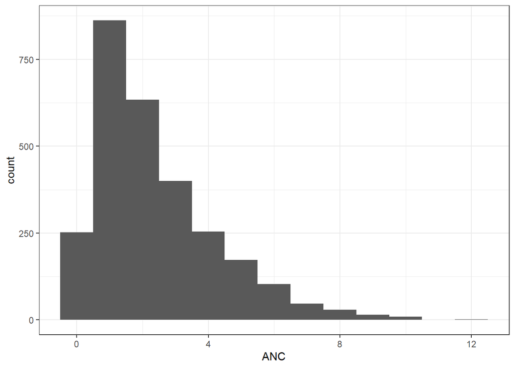

```r
plot_continuous("ANC", 1)
```

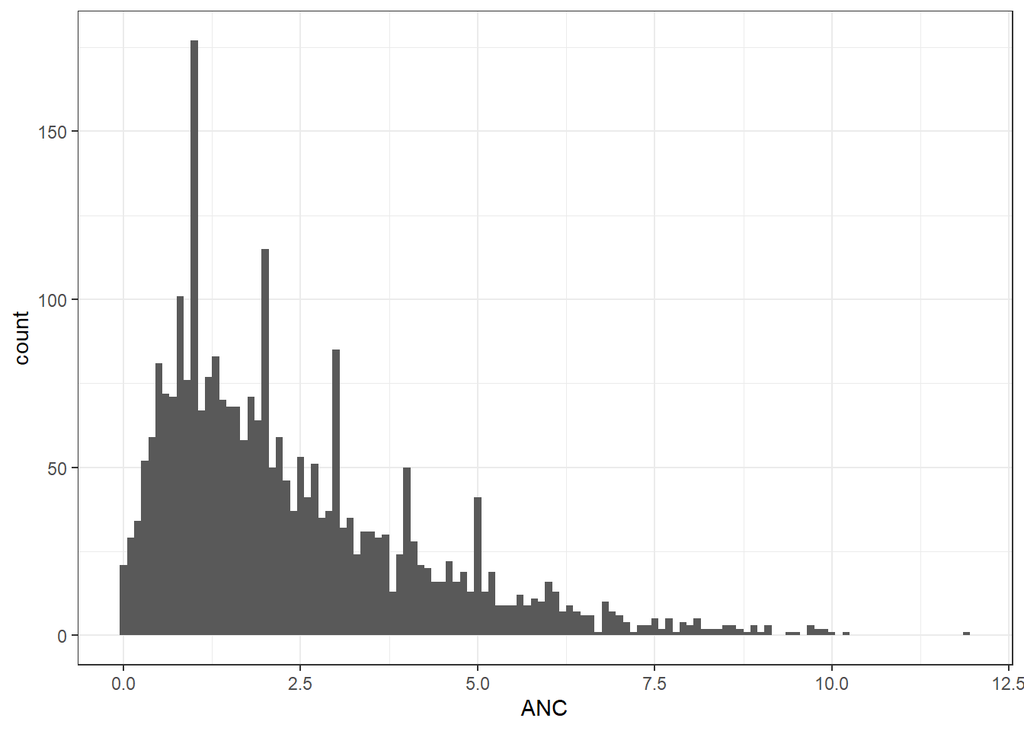

```r
plot_continuous("ANC", 0.1)
```

```r
descrip_continuous("ANC", 10)
```

```
## # A tibble: 11 × 3
##    intervals       n  perc
##    <fct>       <int> <dbl>
##  1 [0,1.19]      856  28.9
##  2 (1.19,2.38]   823  27.8
##  3 (2.38,3.57]   484  16.4
##  4 (3.57,4.76]   284   9.6
##  5 (4.76,5.95]   173   5.9
##  6 (5.95,7.14]    92   3.1
##  7 (7.14,8.33]    36   1.2
##  8 (8.33,9.52]    20   0.7
##  9 (9.52,10.7]     9   0.3
## 10 (10.7,11.9]     1   0
## 11 <NA>          179   6.1
```

### Monocyte Count (Giga/L)

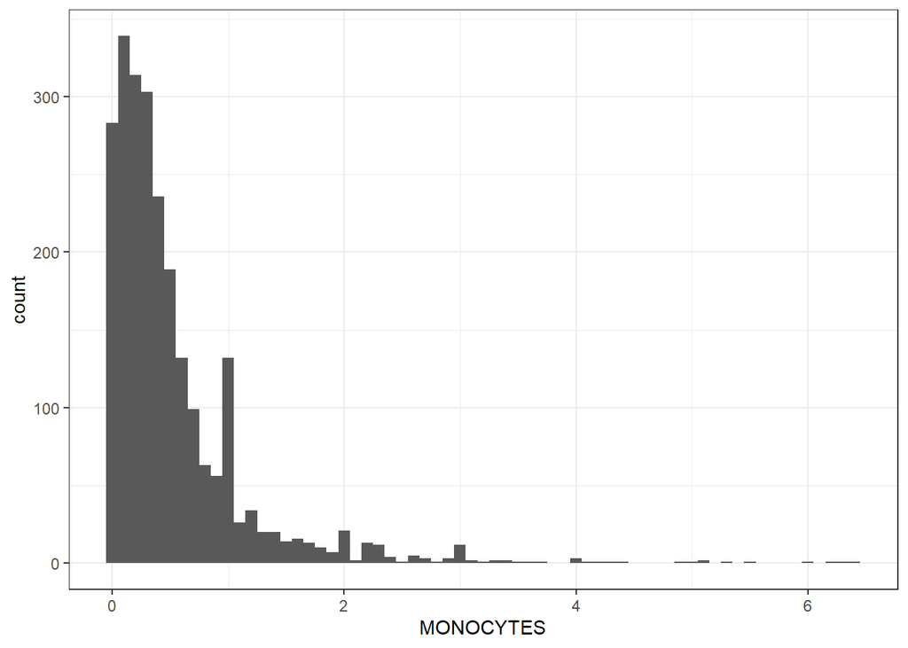

```r
plot_continuous("MONOCYTES", 0.1)
```

```r
descrip_continuous("MONOCYTES", 10)
```

```
## # A tibble: 11 × 3
##    intervals       n  perc
##    <fct>       <int> <dbl>
##  1 [0,0.64]     1788  60.5
##  2 (0.64,1.28]   422  14.3
##  3 (1.28,1.92]    92   3.1
##  4 (1.92,2.56]    57   1.9
##  5 (2.56,3.2]     26   0.9
##  6 (3.2,3.84]      8   0.3
##  7 (3.84,4.48]     7   0.2
##  8 (4.48,5.12]     4   0.1
##  9 (5.12,5.76]     2   0.1
## 10 (5.76,6.4]      4   0.1
## 11 <NA>          547  18.5
```

### Hemoglobin (g/dL)

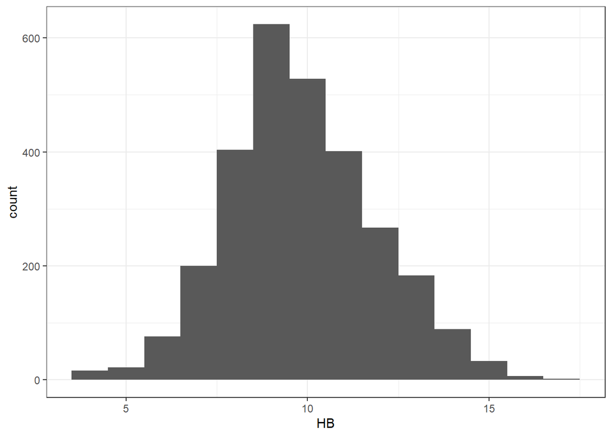

```r
plot_continuous("HB", 1)
```

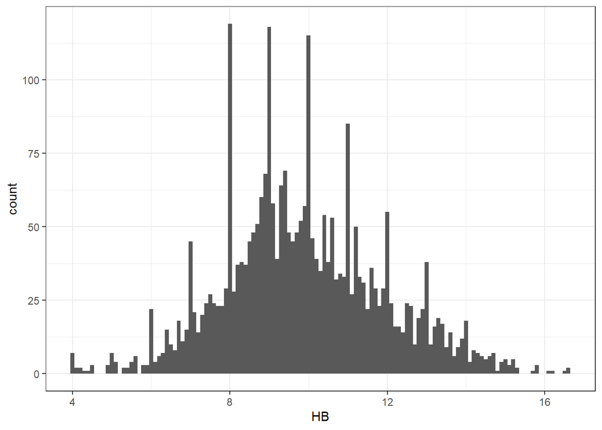

```r
plot_continuous("HB", 0.1)
```

```r
descrip_continuous("HB", 10)
```

```
## # A tibble: 11 × 3
##    intervals       n  perc
##    <fct>       <int> <dbl>
##  1 [4,5.26]       30   1
##  2 (5.26,6.52]    84   2.8
##  3 (6.52,7.78]   251   8.5
##  4 (7.78,9.04]   700  23.7
##  5 (9.04,10.3]   713  24.1
##  6 (10.3,11.6]   494  16.7
##  7 (11.6,12.8]   318  10.8
##  8 (12.8,14.1]   190   6.4
##  9 (14.1,15.3]    63   2.1
## 10 (15.3,16.6]     9   0.3
## 11 <NA>          105   3.6
```

Most samples had hemoglobin proportions between 8 and 12 g/dL.

### Platelets (Giga/L)

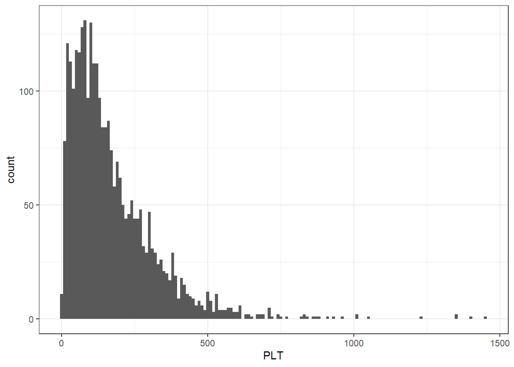

```r
plot_continuous("PLT", 10)
```

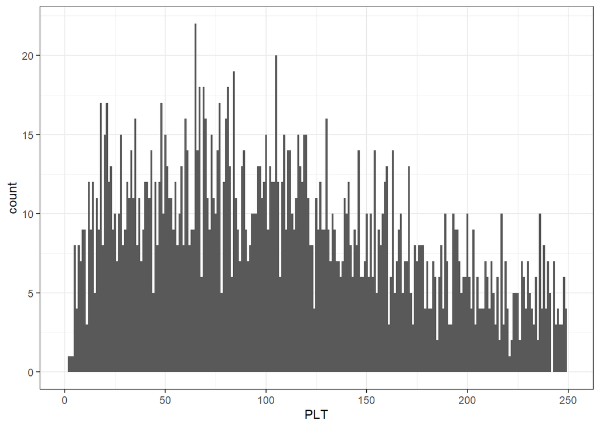

```r
plot_continuous("PLT", 1) +
  xlim(c(0, 250))
```

```r
descrip_continuous("PLT", 10)
```

```
## # A tibble: 11 × 3
##    intervals               n  perc
##    <fct>               <int> <dbl>
##  1 [2,147]              1564  52.9
##  2 (147,292]             795  26.9
##  3 (292,437]             330  11.2
##  4 (437,582]              99   3.3
##  5 (582,726]              29   1
##  6 (726,871]               9   0.3
##  7 (871,1.02e+03]          7   0.2
##  8 (1.02e+03,1.16e+03]     1   0
##  9 (1.16e+03,1.31e+03]     1   0
## 10 (1.31e+03,1.45e+03]     4   0.1
## 11 <NA>                  118   4
```

Most samples had platelet count values below 200 Giga/L. Original studied capped the platelet values to 250.

### Ringed Sideroblasts (Giga/L)

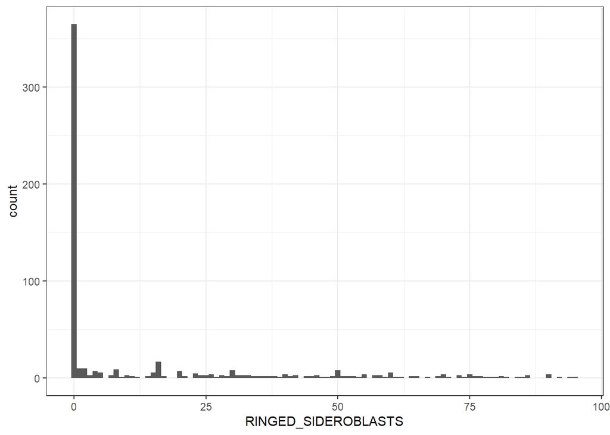

```r
plot_continuous("RINGED_SIDEROBLASTS", 1)
```

```r
descrip_continuous("RINGED_SIDEROBLASTS", 10)
```

```
## # A tibble: 11 × 3
##    intervals     n  perc
##    <fct>     <int> <dbl>
##  1 [0,9.5]     414  14
##  2 (9.5,19]     33   1.1
##  3 (19,28.5]    28   0.9
##  4 (28.5,38]    29   1
##  5 (38,47.5]    18   0.6
##  6 (47.5,57]    25   0.8
##  7 (57,66.5]    16   0.5
##  8 (66.5,76]    18   0.6
##  9 (76,85.5]    10   0.3
## 10 (85.5,95]    10   0.3
## 11 <NA>       2356  79.7
```

Only a small subset of the samples had information about ring sideroblasts. Therefore, we will not include them in the analysis.

## Cytogenetics

```r
cyto <- c("CYTO_IPSSR", "complex", "chr17",
          colnames(clinical_all)[starts_with(c("kar", "mono", "triso", "del"),
  ignore.case = FALSE,
  vars = colnames(clinical_all))],
  "dic", "inv", "mar", "trans")
```

### Cytogenetics IPSSR

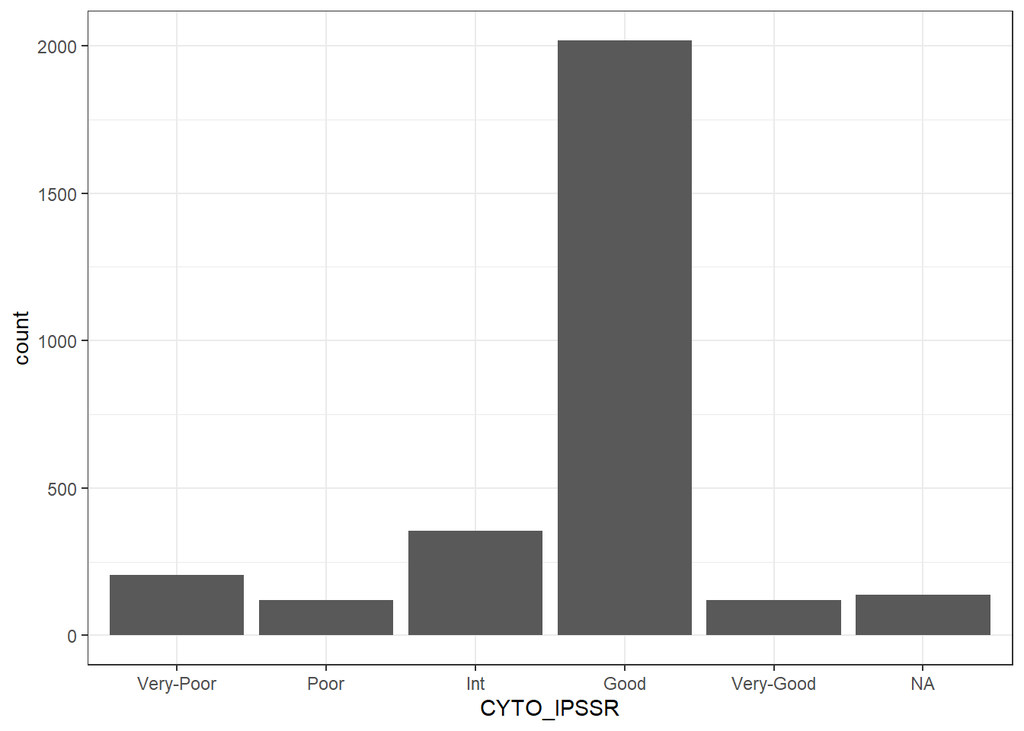

```r
plot_categorical("CYTO_IPSSR")
```

```r
descrip_categorical("CYTO_IPSSR")
```

```
## # A tibble: 6 × 3
##   CYTO_IPSSR     n  perc
##   <fct>      <int> <dbl>
## 1 Very-Poor    206   7
## 2 Poor         121   4.1
## 3 Int          356  12
## 4 Good        2018  68.2
## 5 Very-Good    119   4
## 6 <NA>         137   4.6
```

Most of the individuals presented good or very good cytogenetic results.

### Complex

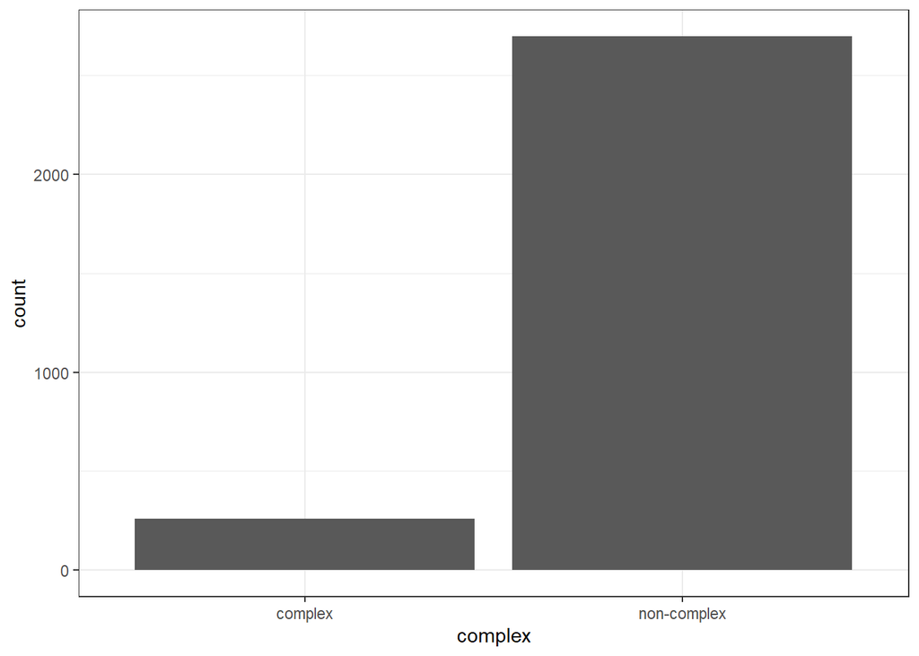

```r
plot_categorical("complex")
```

```r
descrip_categorical("complex")
```

```
## # A tibble: 2 × 3
##   complex         n  perc
##   <chr>       <int> <dbl>
## 1 complex       261   8.8
## 2 non-complex  2696  91.2
```

Some individuals present complex karyotypes.

### Chromosome 17

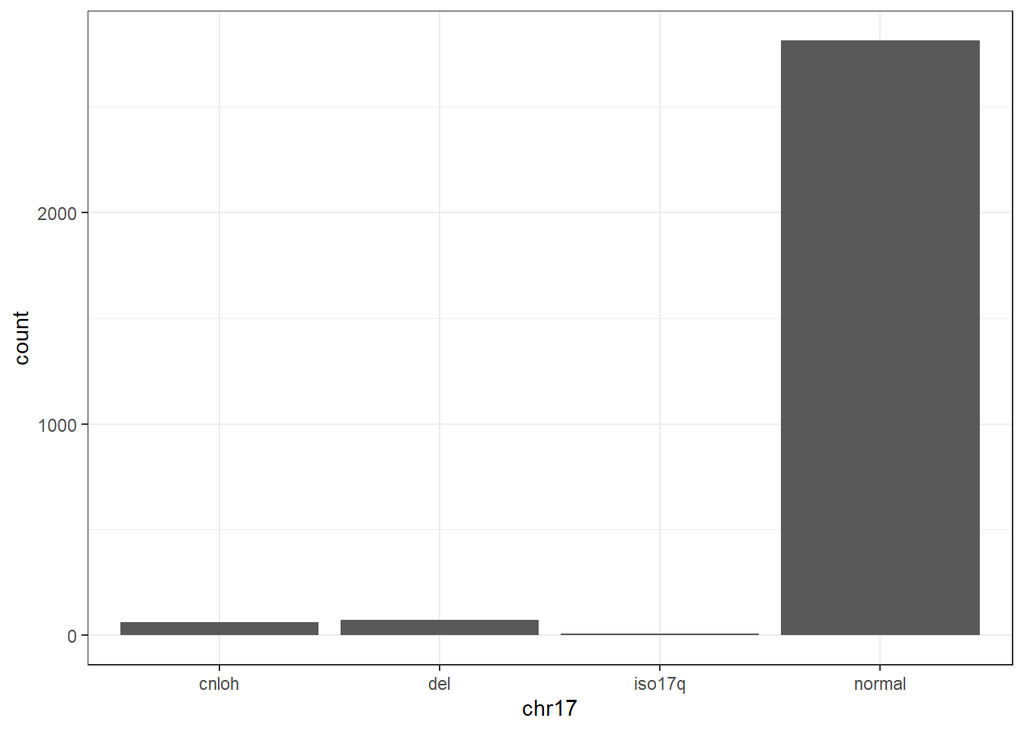

```r
plot_categorical("chr17")
```

```r
descrip_categorical("chr17")
```

```
## # A tibble: 4 × 3
##   chr17      n  perc
##   <chr>  <int> <dbl>
## 1 cnloh     64   2.2
## 2 del       74   2.5
## 3 iso17q     7   0.2
## 4 normal  2812  95.1
```

Some individuals present aberrations in chromosome 17.

### Karyotype events

```r
kar <- c(colnames(clinical_all)[starts_with(c("kar", "mono", "triso", "del", "der"),
  ignore.case = FALSE,
  vars = colnames(clinical_all))],
  "dic", "inv", "mar", "trans", "any_aberration", "dup_rare", "add_rare")
```

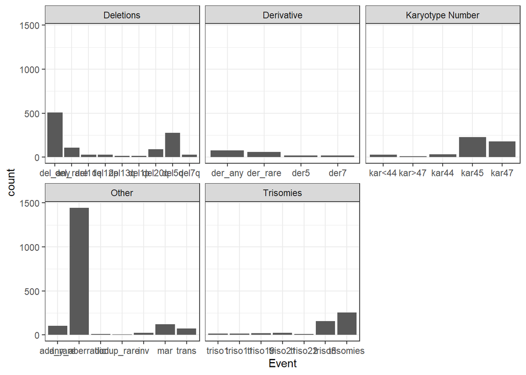

```r
clin_cyto <- clinical_all %>%
  select(kar) %>%
  gather(Event, Value) %>%
  filter(Value != 0) %>%
  mutate(
    Group = case_when(
      str_detect(Event, "mono*") ~ "Monosomies",
      str_detect(Event, "tri.*") ~ "Trisomies",
      str_detect(Event, "kar.*") ~ "Karyotype Number",
      str_detect(Event, "del.*") ~ "Deletions",
      str_detect(Event, "der.*") ~ "Derivative",
      TRUE ~ "Other"
    )
  )

clin_cyto %>%
  filter(!Group %in% c("Monosomies")) %>%
  ggplot(aes(x = Event)) +
    geom_bar() +
  theme_bw() +
  facet_wrap(~ Group, scales = "free_x")
```

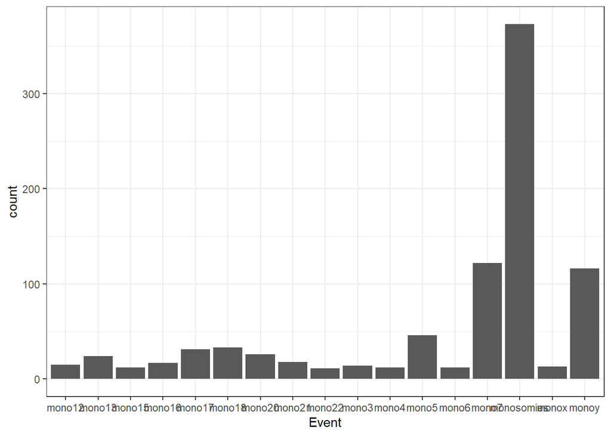

```r
clin_cyto %>%
  filter(Group %in% c("Monosomies")) %>%
  ggplot(aes(x = Event)) +
    geom_bar() +
  theme_bw()
```

```r
clin_cyto %>%
  count(Event) %>%
    mutate(perc = round(n/nrow(clinical_all)*100, 1)) %>%
  arrange(desc(n))
```

```
## # A tibble: 49 × 3
##    Event              n  perc
##    <chr>          <int> <dbl>
##  1 any_aberration  1445  48.9
##  2 del_any          505  17.1
##  3 monosomies       373  12.6
##  4 del5q            276   9.3
##  5 trisomies        253   8.6
##  6 kar45            229   7.7
##  7 kar47            180   6.1
##  8 triso8           158   5.3
##  9 mono7            122   4.1
## 10 mar              119   4
## # ℹ 39 more rows
```

Almost half of the patients had at least a karyotipic aberration. The most common aberrations are deletions, monosomies and trisomies. The most common single event is del5q.

```r
top_kar <- clin_cyto %>%
  count(Event) %>%
    mutate(perc = round(n/nrow(clinical_all)*100, 1)) %>%
  arrange(desc(n)) %>%
  filter(n > 100) %>%
  pull(Event)
```

### Copy number events

```r
cnv <- c(colnames(clinical_all)[starts_with(c("loss", "gain", "upd"),
  ignore.case = FALSE,
  vars = colnames(clinical_all))])
```

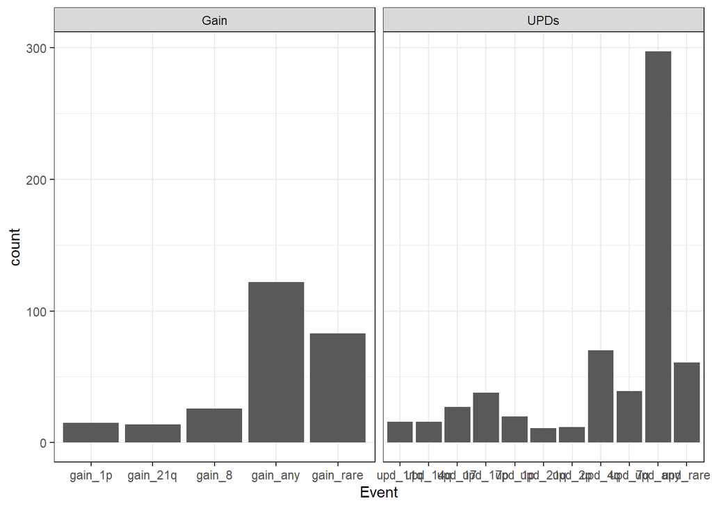

```r
clin_cnv <- clinical_all %>%
  select(cnv) %>%
  gather(Event, Value) %>%
  filter(Value != 0) %>%
  mutate(
    Group = case_when(
      str_detect(Event, "loss*") ~ "Loss",
      str_detect(Event, "gain.*") ~ "Gain",
      str_detect(Event, "upd.*") ~ "UPDs"
    )
  )

clin_cnv %>%
 filter(!Group %in% "Loss") %>%
  ggplot(aes(x = Event)) +
    geom_bar() +
  theme_bw() +
  facet_wrap(~ Group, scales = "free_x")
```

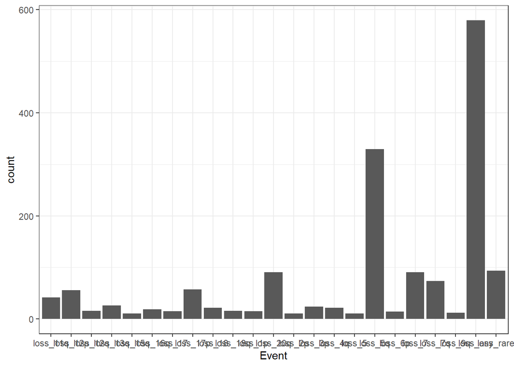

```r
clin_cnv %>%
  filter(Group %in% "Loss") %>%
  ggplot(aes(x = Event)) +
    geom_bar() +
  theme_bw()
```

```r
clin_cnv %>%
  count(Event) %>%
    mutate(perc = round(n/nrow(clinical_all)*100, 1)) %>%
  arrange(desc(n))
```

```
## # A tibble: 39 × 3
##    Event         n  perc
##    <chr>     <int> <dbl>
##  1 loss_any    579  19.6
##  2 loss_5q     329  11.1
##  3 upd_any     297  10
##  4 gain_any    122   4.1
##  5 loss_rare    94   3.2
##  6 loss_20q     91   3.1
##  7 loss_7       91   3.1
##  8 gain_rare    83   2.8
##  9 loss_7q      74   2.5
## 10 upd_4q       70   2.4
## # ℹ 29 more rows
```

Deletions are also the most common cnvs, highlight del5q. Next, UPD events are more frequent than gains. Nonetheless, any other individual event is much infrequent than del5q.

```r
top_cnv <- clin_cnv %>%
  count(Event) %>%
    mutate(perc = round(n/nrow(clinical_all)*100, 1)) %>%
  arrange(desc(n)) %>%
  filter(n > 100) %>%
  pull(Event)
```

## MDS subtypes

```r
mds_types <- c("MDS_TYPE", "WHO_2016")
```

### MDS type

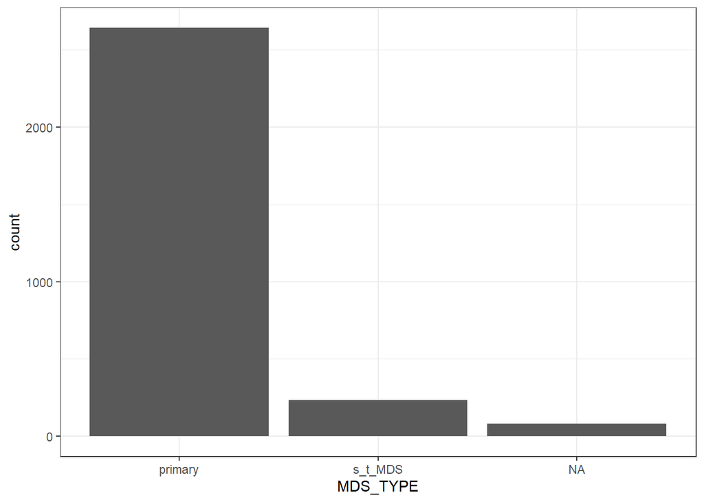

```r
plot_categorical("MDS_TYPE")
```

```r
descrip_categorical("MDS_TYPE")
```

```
## # A tibble: 3 × 3
##   MDS_TYPE     n  perc
##   <chr>    <int> <dbl>
## 1 primary   2641  89.3
## 2 s_t_MDS    234   7.9
## 3 <NA>        82   2.8
```

Most patients are primary MDS. However, a subset where secondary or therapy related MDS.

### WHO subtypes

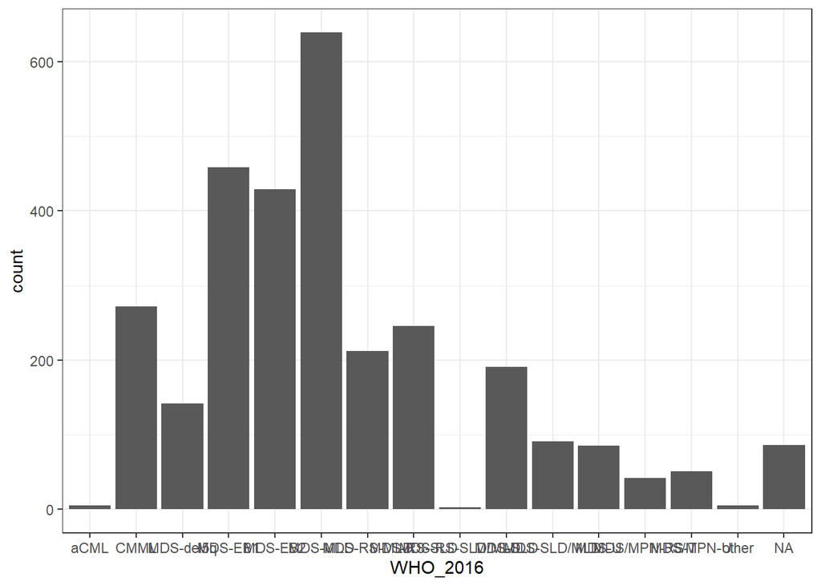

```r
plot_categorical("WHO_2016")
```

```r
descrip_categorical("WHO_2016")  %>%
  arrange(desc(n))
```

```
## # A tibble: 16 × 3
##    WHO_2016           n  perc
##    <chr>          <int> <dbl>
##  1 MDS-MLD          639  21.6
##  2 MDS-EB1          458  15.5
##  3 MDS-EB2          429  14.5
##  4 CMML             272   9.2
##  5 MDS-RS-SLD       246   8.3
##  6 MDS-RS-MLD       212   7.2
##  7 MDS-SLD          191   6.5
##  8 MDS-del5q        142   4.8
##  9 MDS-SLD/MLD       91   3.1
## 10 <NA>              86   2.9
## 11 MDS-U             85   2.9
## 12 MDS/MPN-U         51   1.7
## 13 MDS/MPN-RS-T      42   1.4
## 14 aCML               5   0.2
## 15 other              5   0.2
## 16 MDS-RS-SLD/MLD     3   0.1
```

Most frequent categories are MDS-MLD or MDS with excess of blasts (EB1 and/or EB2)

## IPSS scores

```r
scores <- c("IPSSR", "IPSSR_SCORE", "IPSSRA", "IPSSRA_SCORE", "IPSSM", "IPSSM_SCORE")
```

### IPSSR

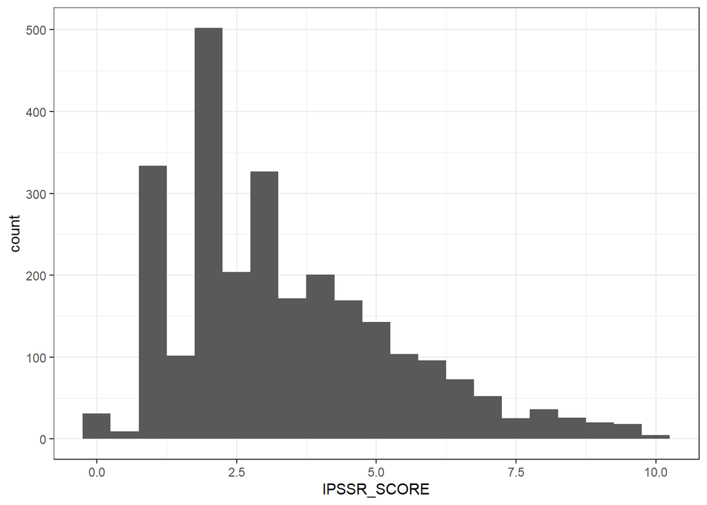

```r
plot_continuous("IPSSR_SCORE", 0.5)
```

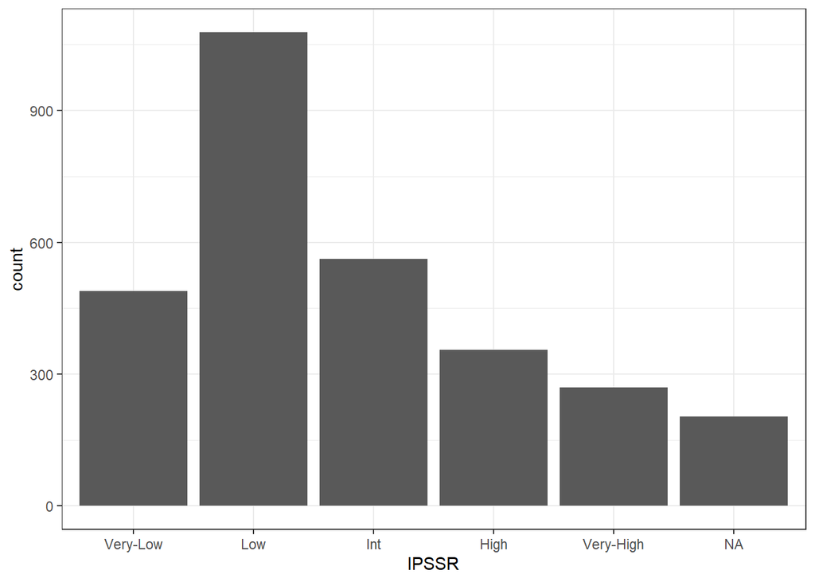

```r
plot_categorical("IPSSR")
```

```r
descrip_categorical("IPSSR")
```

```
## # A tibble: 6 × 3
##   IPSSR         n  perc
##   <fct>     <int> <dbl>
## 1 Very-Low    489  16.5
## 2 Low        1078  36.5
## 3 Int         562  19
## 4 High        355  12
## 5 Very-High   269   9.1
## 6 <NA>        204   6.9
```

Individuals are more likely to have low IPSSR scores. For low scores, there is a tendency to overestimate entire scores (i.e. 1, 2,…)

### IPSSRA

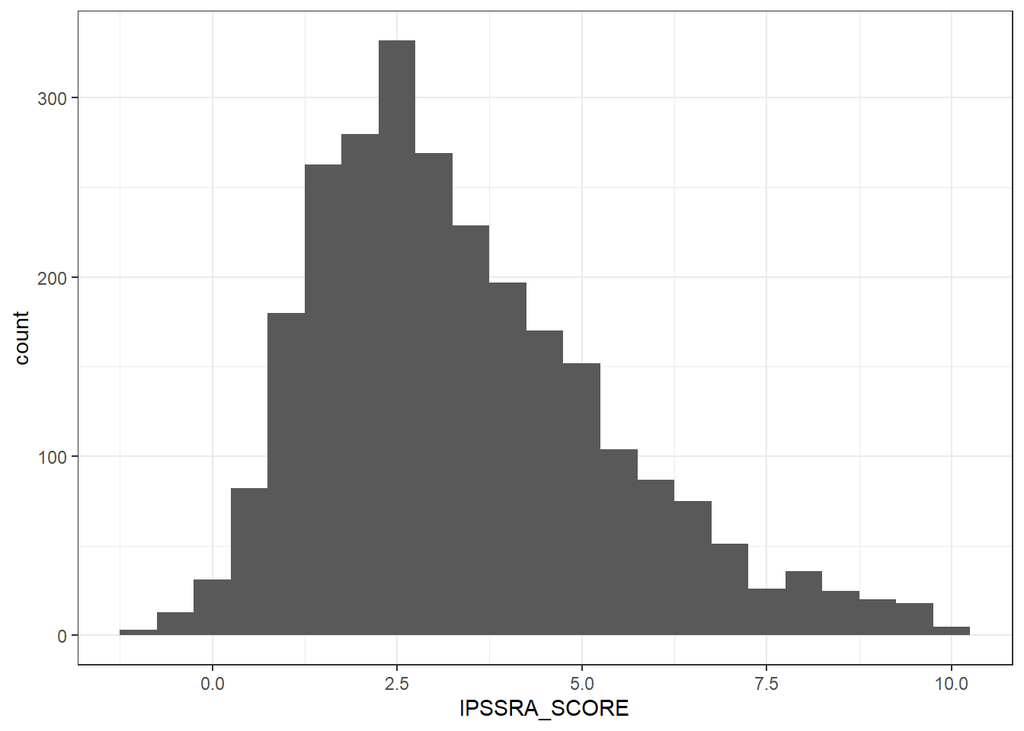

```r
plot_continuous("IPSSRA_SCORE", 0.5)
```

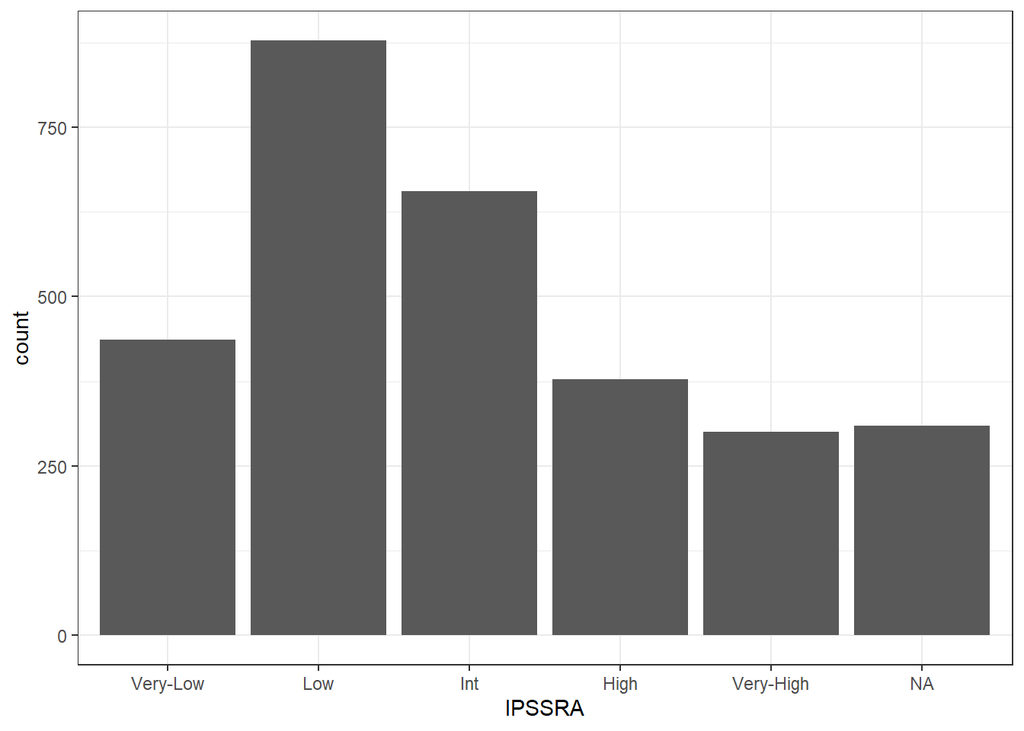

```r
plot_categorical("IPSSRA")
```

```r
descrip_categorical("IPSSRA")
```

```
## # A tibble: 6 × 3
##   IPSSRA        n  perc
##   <fct>     <int> <dbl>
## 1 Very-Low    436  14.7
## 2 Low         878  29.7
## 3 Int         656  22.2
## 4 High        378  12.8
## 5 Very-High   300  10.1
## 6 <NA>        309  10.4
```

The IPSSRA scores show a more normal distribution. Nonetheless, it still predominates the individuals with low scores.